[figure not shown]

## Buffaloes 2015

**Fri Apr 01 15:34:08 2022**

### 1 Overview

The raster GIS layer on Buffaloes (2015) described in this document are part of the **Gridded Livestock of the World database (GLW v4)**.

The GLW database was developped to meet three objectives:

1. Collect, harmonize and disseminate sub-national global data on livestock distribution;
2. Predict livestock numbers in areas with missing informations on livestock census counts;
3. Provide an statistically-informed estimate of how livestock may distribute within census unit through downscaling algoritms.

Two main methods have been described in the litterature for distributing census data at the pixel level. The **areal-weighted (AW)** method simply considers that all pixels of the census area are equally suitable, and assign them an equal weight. It simply corresponds to the density of animals per km<sup>2</sup> in the census unit multiplied by the pixel area. The **dasymetric method (DA)** assigns different weights to different pixels based on high resolution environmental predictor variables and Random Forest models, and the animal census counts are distributed according to these weights.

The **AW** and **DA** GLW global distribution data fit different purposes. The **DA** GLW models provide an estimate of how livestock species may be distributed *within* census areas. However, spatial predictors (e.g. human population density, vegetation indices, topography, etc.) that are used to derived the downscaling weights may introduce some uncontrolled counfonding effects for users willing to quantify the effect of livestock alongside these spatial predictors on an outcome. Similarly, the **DA** models may introduce circularity for users willing to use livestock data to study their impact on some these spatial factors, such as land-use, for example. The **AW** GLW models are free of any influence of spatial predictor variables, but produces more unrealistic distribution patterns, especially in large census areas containing a wide range of different land-use and farming conditions.

This report presents snapshots and links to high resolution maps of the different data layers available with the GLW v4 data package for Buffaloes (2015). Three GIS layers are provided, as geotiff, with an global extent with the projection CRS “+proj=longlat”. The suffix “10k” or “1k” corresponds to a spatial resolution of 0.083333 or 0.0083333 decimal degrees, respectively:

1. **DA GLW model (5_Bf_2015_Da_10k.tif)**: This geotif layer contains the DA animal numbers per pixel, with weight estimated by the Random Forest model. Note that the totals number of animals per census polygon of the DA and AW GLW models should be identical.
2. **AW GLW model (6_Bf_2015_Aw_10k.tif)**: This geotif layer contains the AW animal numbers per pixel in polygons where data where available in the subnational census, and AW predictions from the model in census area where the information was missing.
3. **AW GLW prediction status (7_Bf_2015_Ps_10k.tif)**: This geotif layer contains a value of 0 in pixels where the AW animal number is from a census, and value of 1 if the value was predicted by the GLW model.

### 2 Snapshots

Note that the snapshot below were produced in the equal-area pseudocylindrical Eckert IV projection for a proper representation of densities. The standard lat/long visualisation of global raster data tend to visually over-represent animal densities in pixels located in northern latitudes as they cover a much lower surface on earth than those close to the equator. Altough the data files are distributed in lat/long, we recommend the use of an equal-area projection for displaying our livestock density data.

#### 2.1 Dasymetric GLW model

A high-resolution version can be visualised here.

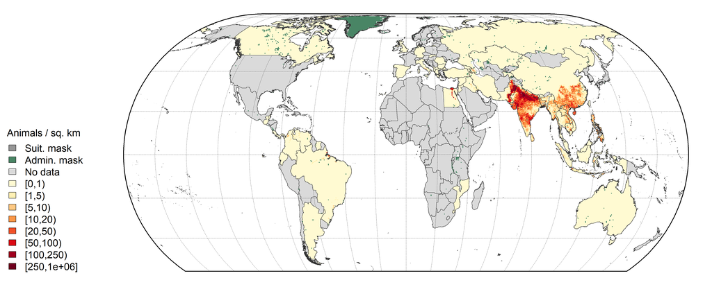

#### 2.2 Areal-weighted GLW model

A high-resolution version can be visualised here.

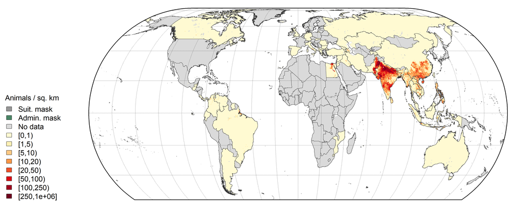

#### 2.3 Areas predicted in the AW model

A high-resolution version can be visualised here.

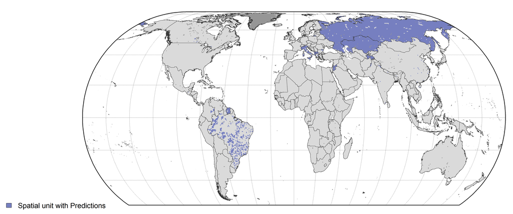

### 3 Description of sub-national census data

#### 3.1 Average Spatial Resolution (ASR)

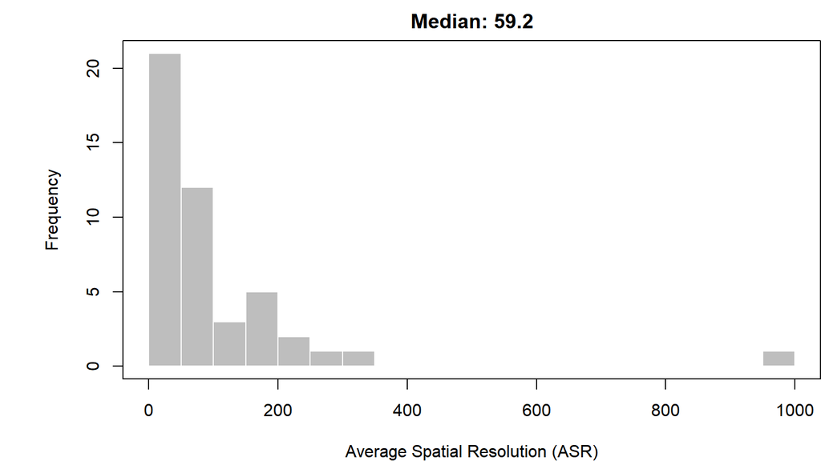

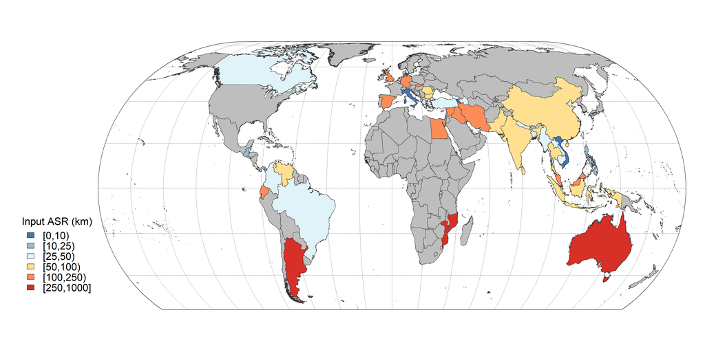

#### 3.2 Year of the sub-national input data

The following histogram and maps show the year of sub-national census data used for the GLW models.

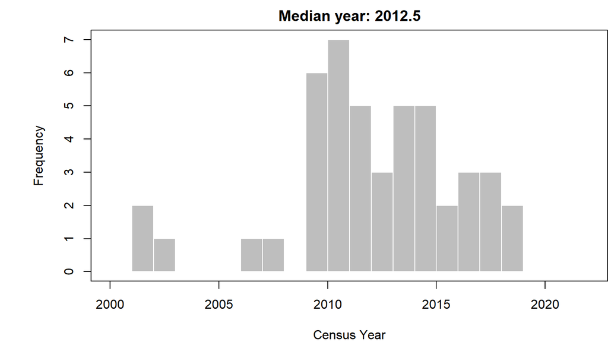

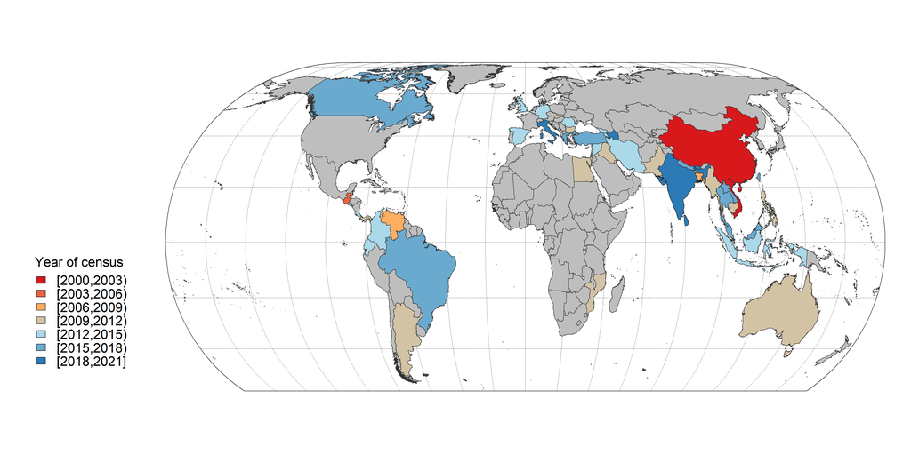

### 4 Goodness of fit of polygon-level predictions

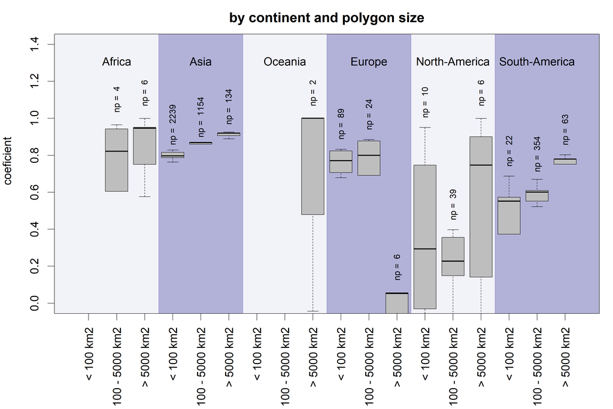

### 5. Citations

The GLW database was originally described by Wint & Robinson (GLW v1, 2007) and used the DA method with weights quantified through stratified multiple regressions. The modelling procedure was automated and standardized for GLW v2 (Robinson *et al.* 2014) and the methodology used to derived the weights was recently improved by replacing stratified linear regression by Random Forest for producing GLW v3.0 (Nicolas *et al.* 2016). This dataset is described in full in Gilbert *et al.* (2018).

- Gilbert M., G. Nicolas, G. Cinardi, G.R.W. Wint, S. Vanwambeke, T.P. Robinson (2018) Global Distribution Data for Cattle, Buffaloes, Horses, Sheep, Goats, Pigs, Chickens and Ducks in 2010. *Sci. Data*. 5:180227 https://doi.org/10.1038/sdata.2018.227
- Nicolas G., TP Robinson, G.R.W. Wint, G. Conchedda, G. Cinardi, M. Gilbert (2016) Using random forest to improve the downscaling of global livestock census data. *Plos ONE* 11(3): e0150424. http://dx.doi.org/10.1371/journal.pone.0150424
- Robinson, T., W. Wint, T, G. Conchedda, T. P. Van Boeckel, V. Ercoli, E. Palamara, G. Cinardi, L. D’Aietti, & M. Gilbert (2014) Mapping the Global Distribution of Livestock. *PLoS ONE* 9(5): e96084. http://dx.doi.org/10.1371/journal.pone.0096084
- Wint, W., and T. Robinson (2007) *Gridded Livestock of the World*. Food and Agricultural Organisation, Rome, Italy.http://www.fao.org/docrep/010/a1259e/a1259e00.htm

### 6. Country census data references

Table continues below

|  | Country | ASR | Year | Census | FAOSTAT | Source |
| --- | --- | --- | --- | --- | --- | --- |
| **ALB** | Albania | NA | NA | NA | 116 | -9999 |
| **ARG** | Argentina | 340.8 | 2011 | 82,094 | NA | Ministerio de Agricultura, Ganadería y Pesca, Argentina |
| **ARM** | Armenia | 5.7 | 2014 | 704 | 720 | National Statistical Service of the Republic of Armenia |
| **AUS** | Australia | 982.3 | 2011 | 4,414 | NA | Australian Bureau of Statistics |
| **AZE** | Azerbaijan | 35.0 | 2018 | 176,195 | 242,294 | The State Statistical Committee of the Republic of Azerbaijan |
| **BGD** | Bangladesh | 46.3 | 2008 | 541,184 | 1,464,000 | Bangladesh Bureau of Statistics |
| **BLZ** | Belize | 61.0 | 2011 | 26 | NA | World Organisation for Animal Health - OIE |
| **BTN** | Bhutan | 13.8 | 2018 | 531 | 586 | Ministry of Agriculture and Forest, Royal Government of Bhutan |
| **BRA** | Brazil | 39.3 | 2017 | 877,621 | 1,370,488 | Istituto Brasileiro de Geografia e Estatistica |
| **BRN** | Brunei Darussalam | NA | NA | NA | 2,942 | -9999 |
| **BGR** | Bulgaria | 63.8 | 2010 | 9,542 | 9,555 | Ministry of Agriculture and Forestry - Agrostatistics Directorate, Bulgaria |
| **KHM** | Cambodia | 31.2 | 2011 | 672,727 | 682,000 | Ministry of Agriculture, Forestry and Fisheries |
| **CAN** | Canada | 44.5 | 2016 | 70,394 | NA | Statistics Canada |
| **CHN** | China | 63.2 | 2002 | 22,723,012 | 27,021,840 | China Agricultural Press |
| **COL** | Colombia | 32.2 | 2014 | 138,233 | 234,994 | Departamento Administrativo Nacional de Estadística, Colombia |
| **CRI** | Costa Rica | 85.8 | 2014 | 4,380 | NA | Instituto Nacional de Estadística y Censos, Costa Rica |
| **ECU** | Ecuador | 105.9 | 2012 | 3,396 | NA | World Organisation for Animal Health - OIE |
| **EGY** | Egypt | 191.0 | 2010 | 3,818,242 | 3,701,559 | Economic Affaire Sector, Ministry of Agriculture and Land Reclamation, Egypt |
| **SWZ** | Eswatini | 65.9 | 2013 | 95 | NA | World Organisation for Animal Health - OIE |
| **GEO** | Georgia | 29.8 | 2014 | 16,024 | 19,300 | National Statistics Office of Georgia |
| **DEU** | Germany | 165.3 | 2013 | 5,850 | 7,972 | European Union Statistical Office - EUROSTAT |
| **GRC** | Greece | 42.0 | 2016 | 3,901 | 5,200 | Hellenic Statistical Authority |
| **GTM** | Guatemala | 18.2 | 2003 | 1,948 | NA | Instituto Nacional de Estadística, Guatemala |
| **HKG** | Hong Kong | NA | NA | NA | 302 | -9999 |
| **IND** | India | 67.6 | 2019 | 109,453,186 | 110,313,638 | Department of Animal Husbandry, Dairying & Fisheries - Ministry of Agriculture - Government of India |
| **IDN** | Indonesia | 65.8 | 2013 | 1,082,393 | 1,346,917 | Badan Pusat Statistik, Republik Indonesia |
| **IRN** | Iran (Islamic Republic of) | 241.0 | 2014 | 106,521 | 101,056 | Statistical Centre of Iran |
| **IRQ** | Iraq | 155.9 | 2010 | 285,537 | 194,391 | World Organisation for Animal Health - OIE |
| **ITA** | Italy | 8.1 | 2019 | 408,497 | 374,458 | Istituto Zooprofilattico Sperimentale dell’Abruzzo e del Molise ‘Giuseppe Caporale’ (IZSAM) |
| **JOR** | Jordan | NA | NA | NA | 99 | -9999 |
| **KAZ** | Kazakhstan | NA | NA | NA | 10,000 | -9999 |
| **LAO** | Lao People’s Democratic Republic | 40.8 | 2017 | 1,194,652 | 1,165,000 | Department of Livestock and Fisheries, Laos |
| **MYS** | Malaysia | 154.0 | 2015 | 120,710 | 118,569 | World Organisation for Animal Health - OIE |
| **MUS** | Mauritius | NA | NA | NA | 25 | -9999 |
| **FSM** | Micronesia (Federated States of) | NA | NA | NA | 161 | -9999 |
| **MOZ** | Mozambique | 256.8 | 2011 | 366 | NA | World Organisation for Animal Health - OIE |
| **MMR** | Myanmar | 45.9 | 2011 | 3,075,813 | 3,531,898 | Livestock Breeding and Veterinary Department (LBVD), Ministry of Livestock Breeding and Fisheries, Yangon,Myanmar |
| **NPL** | Nepal | 44.4 | 2017 | 5,167,807 | 5,167,737 | Ministry of Agriculture and Livestock Development, Nepal |
| **MKD** | North Macedonia | NA | NA | NA | 644 | -9999 |
| **PAK** | Pakistan | 83.9 | 2010 | 25,990,253 | 35,580,000 | Agricultural Census Organization, Ministry of Food & Agriculture, Pakistan |
| **PAN** | Panama | 11.4 | 2011 | 2,394 | NA | Instituto Nacional de Estadística y Censo, Panamá |
| **PHL** | Philippines | 13.8 | 2010 | 2,961,485 | 2,854,838 | Bureau of Agricultural Statistics (BAS) |
| **ROU** | Romania | 76.2 | 2012 | 22,380 | NA | World Organisation for Animal Health - OIE |
| **RUS** | Russian Federation | NA | NA | NA | 6,907 | -9999 |
| **SVK** | Slovakia | 110.7 | 2010 | 500 | NA | Statistical Office of the Slovak Republic |
| **ESP** | Spain | 163.2 | 2012 | 704 | NA | World Organisation for Animal Health - OIE |
| **LKA** | Sri Lanka | 51.6 | 2018 | 308,790 | 323,080 | Department of Census and Statistics Sri Lanka |
| **SUR** | Suriname | NA | NA | NA | 865 | -9999 |
| **SYR** | Syrian Arab Republic | 120.4 | 2012 | 6,375 | 8,000 | World Organisation for Animal Health - OIE |
| **TWN** | Taiwan | 47.3 | 2015 | 2,311 | 2,437 | Agricultural Producion 2015 (https://eng.coa.gov.tw/ws.php?id=2505373) |
| **TJK** | Tajikistan | NA | NA | NA | 15,214 | -9999 |
| **THA** | Thailand | 82.6 | 2015 | 888,431 | 990,000 | World Organisation for Animal Health - OIE |
| **TLS** | Timor-Leste | 34.0 | 2015 | 128,262 | 128,262 | Timor-Leste Population and Housing Census 2015 (http://www.statistics.gov.tl/category/publications/census-publications/) |
| **TUR** | Turkey | 29.1 | 2015 | 126,008 | 121,826 | Turkish Statistical Institute |
| **GBR** | U.K. of Great Britain and Northern Ireland | 246.9 | 2012 | 3,719 | NA | World Organisation for Animal Health - OIE |
| **VEN** | Venezuela | 57.4 | 2007 | 225,790 | NA | Ministerio del Poder Popular para la Agricultura y Tierras - Venezuela |
| **VNM** | Viet Nam | 5.6 | 2001 | 2,778,333 | 2,524,000 | General Statistics Office of Vietnam |

|  | Reference |
| --- | --- |
| **ALB** | -9999 |
| **ARG** | Ganados y Carnes - Anuario 2011 (http://64.76.123.202/site/ganaderia/anuario/index.php) |
| **ARM** | Agricultural Census 2014 of the Republic of Armenia (https://www.armstat.am/en/?nid=124) |
| **AUS** | Agricultural commodities. Agriculture Census 2011 |
| **AZE** | The Agriculture of Azerbaijan 2019 - Statistical Yearbook (https://www.stat.gov.az/menu/6/statistical_yearbooks/?lang=en) |
| **BGD** | Census of Agriculture 2008 |
| **BLZ** | Belize: World Animal Health Information Database (WAHID) - Animal Population 2010-2011 (http://www.oie.int/wahis_2/public/wahid.php/Countryinformation/Animalpopulation) |
| **BTN** | Livestock Statistics 2018 |
| **BRA** | Censo Agropecuário 2017 (https://censoagro2017.ibge.gov.br/templates/censo_agro/resultadosagro/index.html) |
| **BRN** | -9999 |
| **BGR** | Agricultural Census 2010 (http://www.mzh.government.bg/MZH/ShortLinks/SelskaPolitika/Agrostatistics/Structure_agricultural_holdings/Results.aspx) |
| **KHM** | Cambodia Livestock Census 2011 |
| **CAN** | 2016 Census of Agriculture (https://www150.statcan.gc.ca/n1/en/type/data?text=004-0200..004-0242) |
| **CHN** | a) China Level 1/02: China Agric. Press, 2003, and Taiwan Level 0/02: Stat. Office, Executive Yuan. Stat. Yearbook, 2010. b) China Level 3/96: Food and Agric. Stat. Centre, China. Abstract of the 1st … |
| **COL** | Censo Nacional Agropecuario 2014 (http://www.dane.gov.co/index.php/estadisticas-por-tema/agropecuario/censo-nacional-agropecuario-2014#entrega-de-resultados-del-3er-censo-nacional-agropecuario-prelimi… |
| **CRI** | VI Censo Nacional Agropecuario, 2014 (http://www.inec.go.cr/flipbook/cenagrotomoIII/index.html) |
| **ECU** | Ecuador: World Animal Health Information Database (WAHID) - Animal Population 2012 (http://www.oie.int/wahis_2/public/wahid.php/Countryinformation/Animalpopulation) |
| **EGY** | Statistics of Livestock 2010 |
| **SWZ** | Swaziland: World Animal Health Information Database (WAHID) - Animal Population 2012-2013 (http://www.oie.int/wahis_2/public/wahid.php/Countryinformation/Animalpopulation) |
| **GEO** | Agricultural Census of Georgia 2014 |
| **DEU** | Agr_r_animal-Animal populations (http://epp.eurostat.ec.europa.eu/portal/page/portal/agriculture/data/database - last access feb 2014) |
| **GRC** | Hellenic Statistical Authori2016 Farm Structure Survey (http://www.statistics.gr/en/statistics/-/publication/SPK12/2016) |
| **GTM** | IV Censo Nacional Agropecuario, 2003 (http://www.ine.gob.gt/np/agropecuario/tomo%20IV.pdf) - last access 01/2014 |
| **HKG** | -9999 |
| **IND** | 20th Livestock Census 2019 (http://dahd.nic.in/about-us/divisions/statistics) |
| **IDN** | Data Sensus Pertanian 2013 (http://st2013.bps.go.id/dev2/index.php) |
| **IRN** | Iran Statistical Yearbook 2016-2015 |
| **IRQ** | Iraq: World Animal Health Information Database (WAHID) - Animal Population 2008-2010 (http://www.oie.int/wahis_2/public/wahid.php/Countryinformation/Animalpopulation) |
| **ITA** | Anagarafe nazionale zootecnica (BDANI) 2019 |
| **JOR** | -9999 |
| **KAZ** | -9999 |
| **LAO** | L2/2011 Lao Livestock census Data 2011/12 combined with L1/2017 2017 data - Section Provincial |
| **MYS** | Malaysia: Animal Population 2007 - 2015 |
| **MUS** | -9999 |
| **FSM** | -9999 |
| **MOZ** | Mozambique: World Animal Health Information Database (WAHID) - Animal Population 2011-2012 (http://www.oie.int/wahis_2/public/wahid.php/Countryinformation/Animalpopulation) |
| **MMR** | Myanmar Farm Animal Resources:Numbers and Distributions from Administrative Returns, 2011/12 |
| **NPL** | L3/2011 National Census of Agriculture 2011-2012 combined with L2/2017 Livestock Statistics of Nepal 2017 |
| **MKD** | -9999 |
| **PAK** | Agricultural Census 2010 (http://www.pbs.gov.pk/content/agricultural-census-2010-pakistan-report) |
| **PAN** | VII Censo Nacional Agropecuario. Resultados Finales (http://www.contraloria.gob.pa/inec/Publicaciones/subcategoria.aspx?ID_CATEGORIA=15&ID_SUBCATEGORIA=60&ID_IDIOMA=1) |
| **PHL** | Livestock survey Philippines 2010 |
| **ROU** | Romania: World Animal Health Information Database (WAHID) - Animal Population 2008-2012 (http://www.oie.int/wahis_2/public/wahid.php/Countryinformation/Animalpopulation) |
| **RUS** | -9999 |
| **SVK** | Livestock by territory, Products and period |
| **ESP** | Spain: World Animal Health Information Database (WAHID) - Animal Population 2010-2013 (http://www.oie.int/wahis_2/public/wahid.php/Countryinformation/Animalpopulation) |
| **LKA** | Livestock Population by Type and by District - 2017 - 2018 (http://www.statistics.gov.lk/agriculture/Livestock/LivestockPopulationSubnational.html#CattlePopulation) |
| **SUR** | -9999 |
| **SYR** | Syrian Arab Republic: World Animal Health Information Database (WAHID) - Animal Population 2008-2012 (http://www.oie.int/wahis_2/public/wahid.php/Countryinformation/Animalpopulation) |
| **TWN** | Council of Agriculture, Executive Yuan R.O.C., Taiwan |
| **TJK** | -9999 |
| **THA** | Thailand: World Animal Health Information Database (WAHID) - Animal Population 2007-2014 (http://www.oie.int/wahis_2/public/wahid.php/Countryinformation/Animalpopulation) |
| **TLS** | Statistics Timor-Leste, General Directorate of Statistics |
| **TUR** | Livestock Database 2015 (https://biruni.tuik.gov.tr/hayvancilikapp/hayvancilik_ing.zul) |
| **GBR** | United Kingdom: World Animal Health Information Database (WAHID) - Animal Population 2008-2012 (http://www.oie.int/wahis_2/public/wahid.php/Countryinformation/Animalpopulation |
| **VEN** | VII Censo Agrícola - 2007 |
| **VNM** | Agricultural Census database 2001 |